# projekt

2025-05-13

## Zad 1. Podstawowe własności danych

**(a)** Wczytanie danych.

```r
X_train = read.csv("X_train.csv", header = TRUE)
X_test = read.csv("X_test.csv", header = TRUE)
y_train = read.csv("y_train.csv", header = TRUE)
```

Sprawdzenie podstawowych własności danych, takich jak ilość obserwacji oraz zmiennych, typ danych i kompletność danych.

```r
ncol(X_train)
```

```
## [1] 9000
```

```r
nrow(X_train)
```

```
## [1] 6800
```

```r
anyNA(X_train)
```

```
## [1] FALSE
```

```r
str(X_train)
```

```
## 'data.frame':    6800 obs. of  9000 variables:
##  $ LINC01128   : num  0 0 0 0 0 ...
##  $ LINC00115   : num  0 0 0 0 0 0 0 0 0 0 ...
##  $ FAM41C      : num  0 0 0 0 0 0 0 0 0 0 ...
##  $ NOC2L       : num  0 0 0 0 0 0 0 0 0 0 ...
##  $ KLHL17      : num  0 0 0 0 0 0 0 0 0 0 ...
##  $ HES4        : num  0 0 0 0 0 0 0 0 0 0 ...
##  $ ISG15       : num  0 0 0 1.827 0.358 ...
##  $ C1orf159    : num  0 0 0 0 0 0 0 0 0 0 ...
##  $ TNFRSF18    : num  0 0 0 0 0 0 0 0 0 0 ...
##  $ TNFRSF4     : num  0 0 0 0 0 0 0 0 0 0 ...
##  $ SDF4        : num  0 0 0 0 0.62 ...
##  $ B3GALT6     : num  0 0 0 0 0.358 ...
##  $ UBE2J2      : num  0 0 0 0 0 ...
##  $ ACAP3       : num  0 0 0 0 0 0 0 0 0 0 ...
```

[output cut: 86 more lines]

```r
ncol(X_test)
```

```
## [1] 9000
```

```r
nrow(X_test)
```

```
## [1] 1200
```

```r
anyNA(X_test)
```

```
## [1] FALSE
```

```r
str(X_test)
```

```
## 'data.frame':    1200 obs. of  9000 variables:
##  $ LINC01128   : num  0 0 0 0 0 0 0 0 0 0 ...
##  $ LINC00115   : num  0 0 0 0 0 0 0 0 0 0 ...
##  $ FAM41C      : num  0 0 0 0 0 0 0 0 0 0 ...
##  $ NOC2L       : num  0 0 0 0 0 0 0 0 0 0 ...
##  $ KLHL17      : num  0 0 0 0 0 0 0 0 0 0 ...
##  $ HES4        : num  0 0 0 0 0 0 0 0 0 0 ...
##  $ ISG15       : num  0 0 0 0 0 ...
##  $ C1orf159    : num  0 0 0 0 0 0 0 0 0 0 ...
##  $ TNFRSF18    : num  0 0 0 0 0 0 0 0 0 0 ...
##  $ TNFRSF4     : num  0 0 0 0 0 0 0 0 0 0 ...
##  $ SDF4        : num  0 0 0 0 0.63 ...
##  $ B3GALT6     : num  1.34 0 0 0 0 ...
##  $ UBE2J2      : num  0 0.796 0 0 0 ...
##  $ ACAP3       : num  0 0 0 0 0 0 0 0 0 0 ...
```

[output cut: 86 more lines]

```r
ncol(y_train)
```

```
## [1] 1
```

```r
nrow(y_train)
```

```
## [1] 6800
```

```r
anyNA(y_train)
```

```
## [1] FALSE
```

```r
str(y_train)
```

```
## 'data.frame':    6800 obs. of  1 variable:
##  $ CD36: num  2.086 2.146 6.543 2.359 -0.295 ...
```

**(b)** Kilka podstawowych statystyk zmiennej objaśnianej i jej rozkład empiryczny.

```r
summary(y_train)
```

```
##       CD36
##  Min.   :-1.2068
##  1st Qu.:-0.3675
##  Median : 0.4036
##  Mean   : 1.1066
##  3rd Qu.: 2.0484
##  Max.   : 8.7388
```

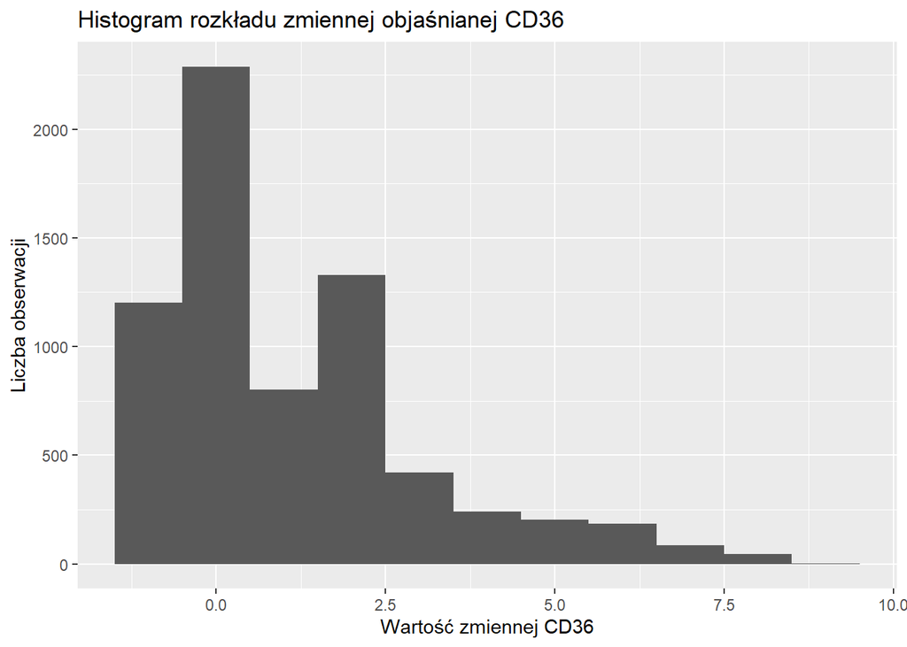

```r
library(ggplot2)
ggplot(y_train) + geom_histogram(aes(x = CD36), binwidth=1) +
  labs(title = "Histogram rozkładu zmiennej objaśnianej CD36", x = "Wartość zmiennej CD36",
       y = "Liczba obserwacji")
```

**(c)** Mapa ciepła korelacji

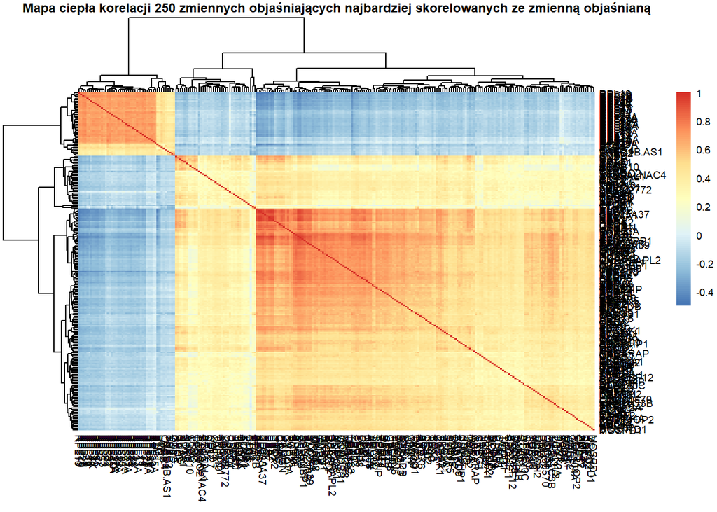

```r
X_train_kor = sapply(X_train, function(x) cor(y_train$CD36,x))

top_kor = names(sort(abs(X_train_kor), decreasing = TRUE))[1:250]
X_top250 = X_train[, top_kor]

cor_matrix = cor(X_top250)

library(pheatmap)
pheatmap(cor_matrix, main = "Mapa ciepła korelacji 250 zmiennych objaśniających najbardziej skorelowanych ze zmienną objaśnianą", fontsize = 7)
```

## Zad 2. Testy statystyczne

**(a)** Wykres kwantylowy porównujący zmienną objaśnianą z rozkładem normalnym

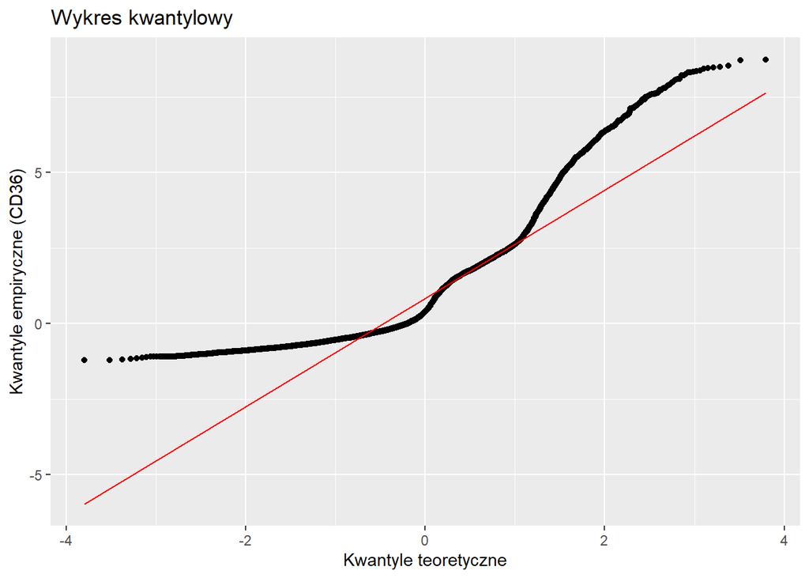

```r
ggplot(y_train, aes(sample = CD36)) + stat_qq() + stat_qq_line(col = 'red') +
  labs(title = "Wykres kwantylowy",
    x = "Kwantyle teoretyczne", y = "Kwantyle empiryczne (CD36)")
```

Na czerwono zaznaczono prostą wyznaczoną przez kwantyle doświadczalne

**(b)** Test zgodności zmiennej objaśnianej z rozkładem normalnym.

**Hipotezowa zerowa $H_0$:** dane pochodzą z rozkładu normalnego.

**Hipoteza alternatywna $H_1$:** dane nie pochodzą z rozkładu normalnego.

**Poziom istotności:** $\alpha$ = 0.05

**Wybór testu:** Wybrałem test Kołmogorowa, ponieważ dane są rozłożone w sposób ciągły i gęsty, więc wydaje się lepszy od testu $\chi^2$.

```r
ks.test(y_train$CD36, "pnorm", mean = mean(y_train$CD36), sd = sd(y_train$CD36))
```

```
##
##  Asymptotic one-sample Kolmogorov-Smirnov test
##
## data:  y_train$CD36
## D = 0.15281, p-value < 2.2e-16
## alternative hypothesis: two-sided
```

**Wnioski:** p-wartość jest bardzo bliska 0, więc z dużym prawdopodobieństwem możemy odrzucić hipotezę, że zmienna pochodzi z rozkładu normalnego.

**(c)**

**i.** Test zgodności zmiennej objaśniającej najbardziej skorelowanej ze zmienną objaśnianą z wybranym rozkładem.

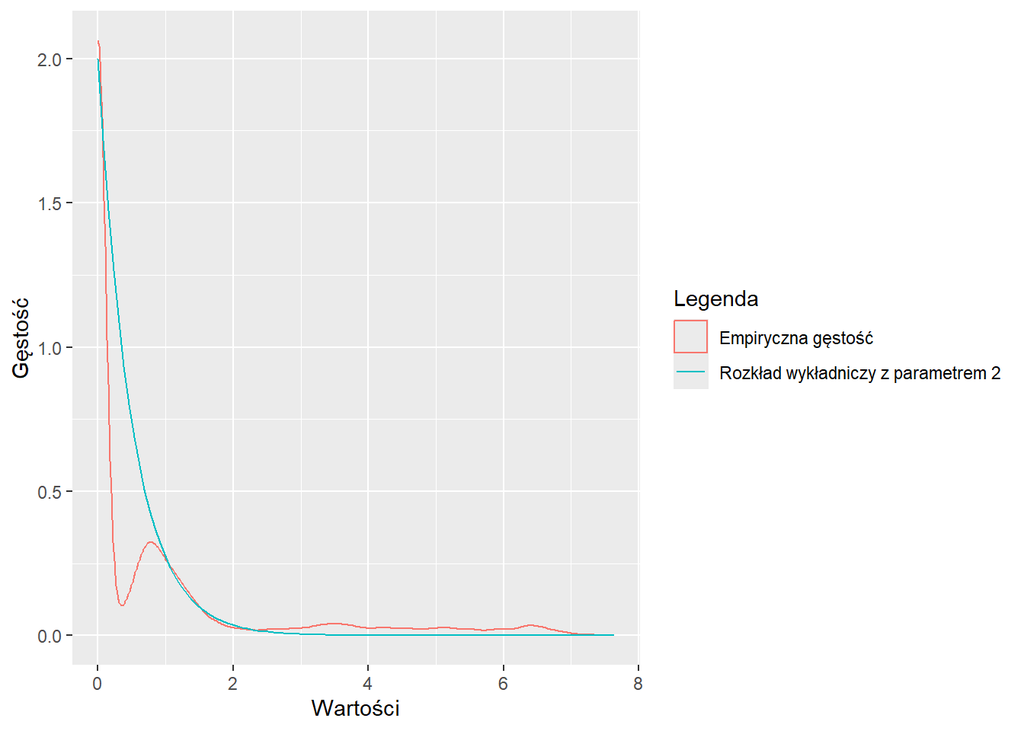

```r
top1_kor = names(sort(abs(X_train_kor), decreasing = TRUE))[1]
X_top1 = X_train[, top1_kor]
X_top1 = data.frame(X_top1)

ggplot(X_top1) + geom_density(aes(x = X_top1, color = 'Empiryczna gęstość')) +
  stat_function(fun = dexp, args = list(rate = 2), aes(color = 'Rozkład wykładniczy z parametrem 2')) +
  labs(color = "Legenda", x = "Wartości", y = "Gęstość")
```

Z wykresu wynika, że sensownie będzie porównać zmienną z rozkładem wykładniczym z parametrem 2.

**Hipotezowa zerowa $H_0$:** dane pochodzą z rozkładu wykładniczego z parametrem 2.

**Hipoteza alternatywna $H_1$:** dane nie pochodzą z rozkładu wykładniczego z parametrem 2.

**Poziom istotności:** $\alpha$ = 0.05

**Wybór testu:** Wybrałem test Kołmogorowa, ponieważ dane są rozłożone w sposób ciągły i gęsty, więc wydaje się lepszy od testu $\chi^2$.

```r
X_top1 = X_train[, top1_kor]
ks.test(X_top1, "pexp", rate = 2)
```

```
##
##  Asymptotic one-sample Kolmogorov-Smirnov test
##
## data:  X_top1
## D = 0.58059, p-value < 2.2e-16
## alternative hypothesis: two-sided
```

**Wnioski:** p-wartość jest bardzo bliska 0, więc z dużym prawdopodobieństwem możemy odrzucić hipotezę, że zmienna pochodzi z rozkładu wykładniczego z parametrem 2.

**ii.** Test podobienśtwa rozkładu zmiennej objaśniającej z (i.) w zbiorze testowym i treningowym.

**Hipotezowa zerowa $H_0$:** rozkłady mają tę samą lokalizację (mediany są równe)

**Hipoteza alternatywna $H_1$:** rozkłady mają różne lokalizacje (mediany są różne)

**Poziom istotności:** $\alpha$ = 0.05

```r
top1_kor = names(sort(abs(X_train_kor), decreasing = TRUE))[1]
X_train_top1 = X_train[, top1_kor]
X_test_top1 = X_test[, top1_kor]
wilcox.test(X_train_top1, X_test_top1)
```

```
##
##  Wilcoxon rank sum test with continuity correction
##
## data:  X_train_top1 and X_test_top1
## W = 4081793, p-value = 0.9784
## alternative hypothesis: true location shift is not equal to 0
```

## Zad 3. Trenowanie modelu ElasticNet

**(a)** Podstawowe informacje o modelu ElasticNet.

ElasticNet to model regresji liniowej z regularizacją, który łączy cechy regresji Lasso (L1) i grzbietowej (Ridge, L2). Stosowany jest w celu poprawy uogólniania modelu, szczególnie gdy zmienne są skorelowane lub liczba cech przekracza liczbę obserwacji.

**Estymowane parametry**

Model estymuje: - $\beta_0$ – wyraz wolny (intercept), - $\boldsymbol{\beta} = (\beta_1, \beta_2, ..., \beta_p)$ – współczynniki regresji dla zmiennych wejściowych.

**Optymalizowana funkcja**

ElasticNet minimalizuje funkcję:

$$\frac{1}{2n} \sum_{i=1}^n \left(y_i - \beta_0 - \mathbf{x}_i^T
\boldsymbol{\beta} \right)^2 + \lambda \left[ (1 - \alpha) \frac{1}{2}
||\boldsymbol{\beta}||_2^2 + \alpha ||\boldsymbol{\beta}||_1 \right]$$

gdzie: - $n$ – liczba obserwacji, - $\lambda \geq 0$ – współczynnik regularyzacji (siła kary), - $\alpha \in [0, 1]$ – parametr mieszający, określający udział kar L1 i L2.

**Hiperparametry**

- $\alpha$
  - $\alpha = 1$ → czysta **regresja Lasso** (tylko kara L1),
  - $\alpha = 0$ → czysta **regresja grzbietowa** (tylko kara L2),
  - $0 < \alpha < 1$ → **ElasticNet** (kombinacja L1 i L2).
- $\lambda$ – określa siłę regularizacji: większa wartość prowadzi do prostszego modelu poprzez silniejsze ograniczanie współczynników.

ElasticNet łączy zalety obu metod: eliminuje nieistotne zmienne (jak Lasso) oraz radzi sobie z kolinearnością (jak Ridge).

**(b)** Użycie walidacji krzyżowej do znalezienia odpowiednich hiperparametrów.

```r
library(glmnet)
library(caret)
X_train_mat = as.matrix(X_train)
y_train_vec = as.numeric(y_train[, 1])

set.seed(123)
folds = createFolds(y_train_vec, k = 5, returnTrain = TRUE)

train_control = trainControl(method = "cv", index = folds, savePredictions = "all")

grid = expand.grid(alpha = c(0, 0.5, 1), lambda = c(0.01, 0.1, 1))
```

Do walidacji krzyżowej użyłem 5 podzbiorów, ponieważ zbiór danych jest duży, więc to będzie dobry kompromis między dokładnością a czasem.

```r
set.seed(123)
model = train(x = X_train_mat, y = y_train_vec, method = "glmnet", tuneGrid = grid,
              trControl = train_control, metric = "RMSE")
print(model)
```

```
## glmnet
##
## 6800 samples
## 9000 predictors
##
## No pre-processing
## Resampling: Cross-Validated (10 fold)
## Summary of sample sizes: 5440, 5440, 5440, 5440, 5440
## Resampling results across tuning parameters:
##
##   alpha  lambda  RMSE       Rsquared   MAE
##   0.0    0.01    0.6052555  0.9026603  0.4444843
##   0.0    0.10    0.6052555  0.9026603  0.4444843
##   0.0    1.00    0.6052555  0.9026603  0.4444843
##   0.5    0.01    0.4570183  0.9426209  0.3271551
##   0.5    0.10    0.5090128  0.9307607  0.3734627
##   0.5    1.00    1.0203940  0.8362401  0.8741634
##   1.0    0.01    0.4566648  0.9426825  0.3267855
##   1.0    0.10    0.5656174  0.9182467  0.4280789
##   1.0    1.00    1.4242782  0.7648985  1.1861963
##
## RMSE was used to select the optimal model using the smallest value.
## The final values used for the model were alpha = 1 and lambda = 0.01.
```

Używając błędu średniokwadratowego jako miary najlepszymi parametrami są $\alpha$ = 1 i $\lambda$ = 0.01.

**(c)** Wykresy skrzypcowe dla błędów średniokwadratowych, otrzymanych w poszczególnych foldach testowych walidacji krzyżowej dla danego zestawu wartości hiperparametrów.

```r
library(dplyr)
```

```r
preds = model$pred

preds_to_plot = data.frame(alpha = numeric(), lambda = numeric(),
                           Resample = character(), MSE = numeric())
for (a in c(0, 0.5, 1)) {
  for (l in c(0.01, 0.1, 1)) {
    for (r in c('Fold1', 'Fold2', 'Fold3', 'Fold4', 'Fold5')) {

      temp = preds[preds$alpha == a & preds$lambda == l & preds$Resample == r, ]
      mse = mean((temp$obs - temp$pred)^2)
      preds_to_plot = rbind(preds_to_plot, data.frame(alpha = a, lambda = l, Resample = r, MSE = mse))
    }
  }
}

preds_to_plot_001 = preds_to_plot[preds_to_plot$lambda == 0.01,]
preds_to_plot_01 = preds_to_plot[preds_to_plot$lambda == 0.1,]
preds_to_plot_1 = preds_to_plot[preds_to_plot$lambda == 1,]

plot001 = ggplot(preds_to_plot_001, aes(x = factor(alpha), y = MSE, fill = factor(alpha))) +
  geom_violin(trim = FALSE, alpha = 0.5) + geom_point(size = 2) +
  labs(title = "lambda = 0.01",x = "alpha",
       y = "MSE", fill = "alpha") + theme_minimal()

plot01 = ggplot(preds_to_plot_01, aes(x = factor(alpha), y = MSE, fill = factor(alpha))) +
  geom_violin(trim = FALSE, alpha = 0.5) + geom_point(size = 2) +
  labs(title = "lambda = 0.1",x = "alpha",
       y = "MSE", fill = "alpha") + theme_minimal()

plot1 = ggplot(preds_to_plot_1, aes(x = factor(alpha), y = MSE, fill = factor(alpha))) +
  geom_violin(trim = FALSE, alpha = 0.5) + geom_point(size = 2) +
  labs(title = "lambda = 1",x = "alpha",
       y = "MSE", fill = "alpha") + theme_minimal()
```

Wykres porównujący wszystkie wykresy skrzypcowe:

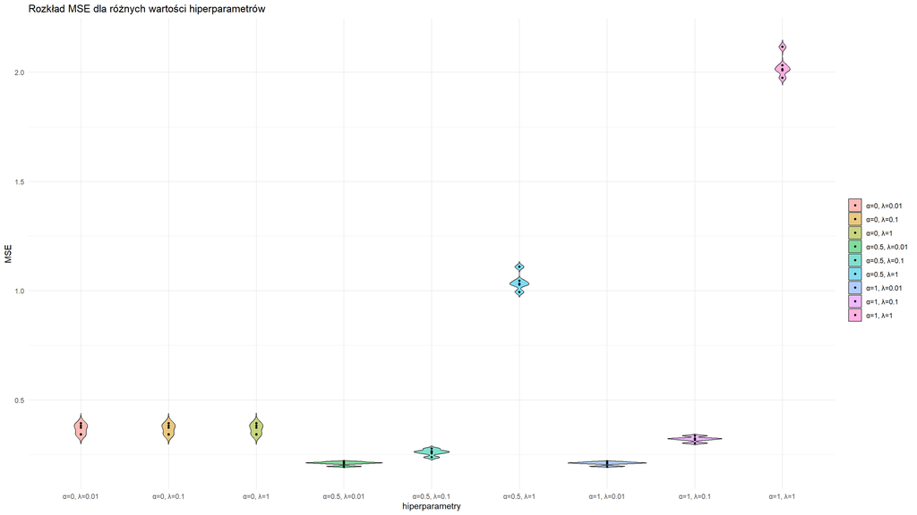

```r
preds_to_plot$al = paste0("α=", preds_to_plot$alpha, ", λ=", preds_to_plot$lambda)

ggplot(preds_to_plot, aes(x = al, y = MSE, fill = al)) +
  geom_violin(trim = FALSE, alpha = 0.5) + geom_point(size = 1) +
  labs(title = 'Rozkład MSE dla różnych wartości hiperparametrów',x = "hiperparametry",
       y = "MSE", fill = "") + theme_minimal()
```

Bardziej czytelne wykresy:

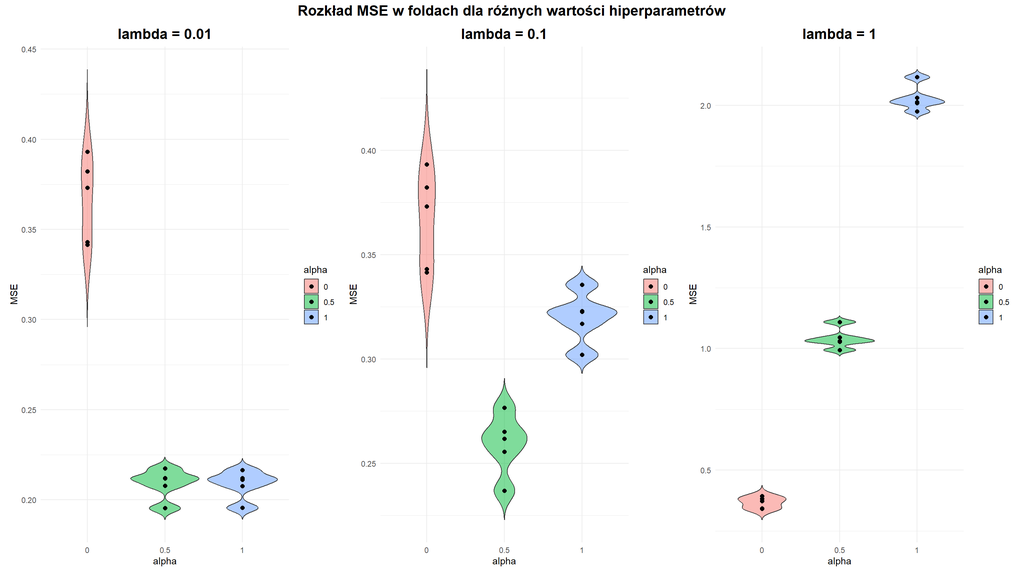

```r
library(patchwork)
(plot001 | plot01 | plot1) +
  plot_annotation(title = "Rozkład MSE w foldach dla różnych wartości hiperparametrów") &
  theme(plot.title = element_text(hjust = 0.5, size = 16, face = "bold"))
```

**(d)** Błąd treningowy i walidacyjny modelu dla wybranych wartości hiperparametrów.

```r
library(glmnet)
X_train_mat = as.matrix(X_train)
y_train_vec = as.numeric(y_train[,1])

calculate_mse = function(fold_name) {
  pred_fold = model$pred[model$pred$Resample == fold_name & model$pred$alpha == model$bestTune$alpha &
                           model$pred$lambda == model$bestTune$lambda, ]
  test_idx = pred_fold$rowIndex

  X_train_fold = X_train_mat[-test_idx, ]
  y_train_fold = y_train_vec[-test_idx]

  mod = glmnet(X_train_fold, y_train_fold, alpha = model$bestTune$alpha, lambda = model$bestTune$lambda)

  pred_train = predict(mod, X_train_fold)

  mse = mean((pred_train - y_train_fold)^2)

  return(mse)
}

folds1 = paste0("Fold", 1:5)

mse_values = sapply(folds1, calculate_mse)

mean_mse_train = mean(mse_values)

mse_test = (model$results$RMSE[model$results$alpha == model$bestTune$alpha & model$results$lambda == model$bestTune$lambda])^2
```

$\alpha$ = 1, $\lambda$ = 0.01

Błąd treningowy: 0.1347405

Błąd walidacyjny: 0.2085428

## Zad 4. Trenowanie modelu lasów losowych.

**(a)** Użycie walidacji krzyżowej do znalezienia odpowiednich hiperparametrów. Użyto te same foldy co w Zad 3.

```r
mtry_values = c(10, 20)
min_node_values = c(10, 20)
num_trees_values = c(30, 50)

models_list = list()
results_list = list()
i = 1

for (ntree in num_trees_values) {
  grid_rf = expand.grid(mtry = mtry_values, min.node.size = min_node_values, splitrule = c("variance"))

  set.seed(123)
  tmp_model = train(x = X_train_mat, y = y_train_vec, method = "ranger", tuneGrid = grid_rf,
    trControl = train_control, num.trees = ntree, metric = "RMSE")

  models_list[[paste0("ntree_", ntree)]] = tmp_model

  tmp_results = tmp_model$results
  tmp_results$num.trees = ntree
  results_list[[i]] = tmp_results
  i = i + 1
}

all_results_rf = bind_rows(results_list)

all_results_rf = arrange(all_results_rf, RMSE)

print(models_list)
```

```
## $ntree_30
## Random Forest
##
## 6800 samples
## 9000 predictors
##
## No pre-processing
## Resampling: Cross-Validated (10 fold)
## Summary of sample sizes: 5440, 5440, 5440, 5440, 5440
## Resampling results across tuning parameters:
##
##   mtry  min.node.size  RMSE       Rsquared   MAE
##   10    10             0.6749243  0.8909167  0.5120440
##   10    20             0.6780708  0.8901929  0.5149552
##   20    10             0.6243318  0.9024755  0.4625216
##   20    20             0.6269548  0.9019229  0.4665894
##
## Tuning parameter 'splitrule' was held constant at a value of variance
## RMSE was used to select the optimal model using the smallest value.
## The final values used for the model were mtry = 20, splitrule = variance
##  and min.node.size = 10.
##
## $ntree_50
## Random Forest
##
## 6800 samples
## 9000 predictors
##
## No pre-processing
## Resampling: Cross-Validated (10 fold)
## Summary of sample sizes: 5440, 5440, 5440, 5440, 5440
## Resampling results across tuning parameters:
##
##   mtry  min.node.size  RMSE       Rsquared   MAE
##   10    10             0.6659557  0.8955758  0.5056799
##   10    20             0.6675939  0.8959085  0.5079989
##   20    10             0.6106858  0.9074307  0.4540723
##   20    20             0.6182814  0.9053990  0.4605138
##
## Tuning parameter 'splitrule' was held constant at a value of variance
## RMSE was used to select the optimal model using the smallest value.
## The final values used for the model were mtry = 20, splitrule = variance
##  and min.node.size = 10.
```

```r
RMSE30 = models_list[[1]]$results$RMSE[models_list[[1]]$results$mtry == models_list[[1]]$bestTune$mtry & models_list[[1]]$results$min.node.size == models_list[[1]]$bestTune$min.node.size]
RMSE50 = models_list[[2]]$results$RMSE[models_list[[2]]$results$mtry == models_list[[2]]$bestTune$mtry & models_list[[2]]$results$min.node.size == models_list[[2]]$bestTune$min.node.size]

if(RMSE30 <= RMSE50){
  bTune = 1
  Bntree = 30
}else{
  bTune = 2
  Bntree = 50
}

Bmtry = models_list[[bTune]]$bestTune$mtry
Bmns = models_list[[bTune]]$bestTune$min.node.size
```

Najlepsze parametry to: ntree = 50, mtry = 20, min.node.size = 10.

**(b)** Wykres pudełkowy dla błędów średniokwadratowych, otrzymanych w poszczególnych foldach testowych walidacji krzyżowej dla danego zestawu wartości hiperparametrów.

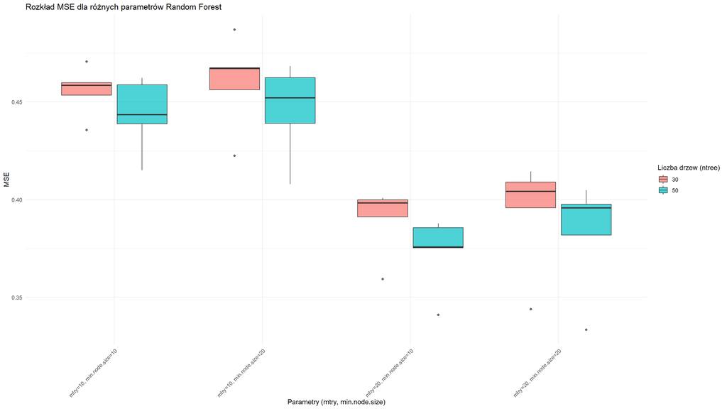

```r
pred_ntree30 = models_list[[1]]$pred
pred_ntree50 = models_list[[2]]$pred

rf_preds_to_plot = data.frame(mtry = numeric(), min.node.size = numeric(), ntree = numeric(),
                           Resample = character(), MSE = numeric())
for (mtr in c(10, 20)) {
  for (mns in c(10, 20)){
    for (r in c('Fold1', 'Fold2', 'Fold3', 'Fold4', 'Fold5')) {

      temp = pred_ntree30[pred_ntree30$mtry == mtr & pred_ntree30$min.node.size == mns & pred_ntree30$Resample == r, ]
      mse = mean((temp$obs - temp$pred)^2)
      rf_preds_to_plot = rbind(rf_preds_to_plot, data.frame(mtry = mtr, min.node.size = mns, ntree = 30,
                                                            Resample = r, MSE = mse))
    }
  }
}

for (mtr in c(10, 20)) {
  for (mns in c(10, 20)){
    for (r in c('Fold1', 'Fold2', 'Fold3', 'Fold4', 'Fold5')) {

      temp = pred_ntree50[pred_ntree50$mtry == mtr & pred_ntree50$min.node.size == mns & pred_ntree50$Resample == r, ]
      mse = mean((temp$obs - temp$pred)^2)
      rf_preds_to_plot = rbind(rf_preds_to_plot, data.frame(mtry = mtr, min.node.size = mns, ntree = 50,
                                                            Resample = r, MSE = mse))
    }
  }
}

library(ggplot2)

rf_preds_to_plot$param_combo = paste0('mtry=', rf_preds_to_plot$mtry,
                                       ', min.node.size=', rf_preds_to_plot$min.node.size)

ggplot(rf_preds_to_plot, aes(x = param_combo, y = MSE, fill = factor(ntree))) +
  geom_boxplot(alpha = 0.7) +
  labs(title = 'Rozkład MSE dla różnych parametrów Random Forest',
       x = 'Parametry (mtry, min.node.size)',
       y = 'MSE',
       fill = 'Liczba drzew (ntree)') +
  theme_minimal() +
  theme(axis.text.x = element_text(angle = 45, hjust = 1))
```

**(c)** Błąd treningowy i walidacyjny modelu dla wybranych wartości hiperparametrów.

```r
library(ranger)

best_model = models_list[[bTune]]
best_model
```

```
## Random Forest
##
## 6800 samples
## 9000 predictors
##
## No pre-processing
## Resampling: Cross-Validated (10 fold)
## Summary of sample sizes: 5440, 5440, 5440, 5440, 5440
## Resampling results across tuning parameters:
##
##   mtry  min.node.size  RMSE       Rsquared   MAE
##   10    10             0.6659557  0.8955758  0.5056799
##   10    20             0.6675939  0.8959085  0.5079989
##   20    10             0.6106858  0.9074307  0.4540723
##   20    20             0.6182814  0.9053990  0.4605138
##
## Tuning parameter 'splitrule' was held constant at a value of variance
## RMSE was used to select the optimal model using the smallest value.
## The final values used for the model were mtry = 20, splitrule = variance
##  and min.node.size = 10.
```

```r
calculate_mse_rf = function(fold_name) {
  pred_fold = best_model$pred[best_model$pred$Resample == fold_name &
                                best_model$pred$mtry == Bmtry &
                                best_model$pred$min.node.size == Bmns, ]
  test_idx = pred_fold$rowIndex

  X_train_fold = X_train_mat[-test_idx, ]
  y_train_fold = y_train_vec[-test_idx]

  mod = ranger(dependent.variable.name = NULL,
               x = X_train_fold,
               y = y_train_fold,
               mtry = Bmtry,
               min.node.size = Bmns,
               num.trees = Bntree)

  pred_train = predict(mod, data = data.frame(X_train_fold))$predictions
  mse = mean((pred_train - y_train_fold)^2)

  return(mse)
}

folds1 = paste0("Fold", 1:5)
mse_values_rf = sapply(folds1, calculate_mse_rf)

mean_mse_train_rf = mean(mse_values_rf)

mse_test_rf = (best_model$results$RMSE[best_model$results$mtry == Bmtry &
                                         best_model$results$min.node.size == Bmns])^2
```

ntree = 50, mtry = 20, min.node.size = 10

Błąd treningowy: 0.0963232

Błąd walidacyjny: 0.3729372

## Zad 5. Podsumowanie

Podsumowanie tabelaryczne wyników modeli ElasticNet, RandomForest i modelu referencyjnego, , który dowolnym wartościom zmiennych objaśniających w foldzie testowym przypisuje średnią arytmetyczną zmiennej objaśnianej policzoną w foldach treningowych.

```r
ref_mse_per_fold_tr = c()
ref_mse_per_fold_vl = c()

for (fold_name in names(folds)) {
  train_idx = folds[[fold_name]]
  test_idx = setdiff(1:length(y_train_vec), train_idx)

  y_train_fold = y_train_vec[train_idx]
  mean_y = mean(y_train_fold)

  y_test = y_train_vec[test_idx]
  y_pred_vl = rep(mean_y, length(y_test))
  y_pred_tr = rep(mean_y, length(y_train_fold))

  mse_vl = mean((y_test - y_pred_vl)^2)
  mse_tr = mean((y_train_fold - y_pred_tr)^2)

  ref_mse_per_fold_tr = c(ref_mse_per_fold_tr, mse_tr)
  ref_mse_per_fold_vl = c(ref_mse_per_fold_vl, mse_vl)
}

model_avgs = data.frame(Model = c("ElasticNet", "RandomForest", "Referencyjny"),
                        MSE_treningowy = c(mean_mse_train, mean_mse_train_rf, mean(ref_mse_per_fold_tr)),
                        MSE_walidacyjny = c(mse_test, mse_test_rf, mean(ref_mse_per_fold_vl)))
print(model_avgs)
```

```
##          Model MSE_treningowy MSE_walidacyjny
## 1   ElasticNet     0.13474050       0.2085428
## 2 RandomForest     0.09632323       0.3729372
## 3 Referencyjny     3.62657836       3.6266936
```

Model ElasticNet osiągnął prawie dwa razy mniejszy błąd walidacyjny niż RandomForest i większy, ale dość zbliżony błąd treningowy. Duża różnica w błędzie walidacyjnym może wynikać z faktu, że w przypadku RandomForest użyłem ograniczoną siatkę hiperparametrów oraz mniejszą liczbę drzew, aby znacząco skrócić czas działania modelu. Chęć uzyskania zadowalającej złożoności czasowej mogła wpłynąć na obniżenie efektywności modelu RandomForest. ElasticNet korzystał z niezależnego od takich ograniczeń doboru parametrów i uzyskał znacząco niższą wartość błędu walidacyjnego, zatem ten model wydaje mi się lepszy.